# SP_DemTech2_Problem Set 4

Sara Peters

2023-10-11

###Soc 756

#Problem Set 4

#Increment Decrement Life Tables

Table 1 (on the class web page) includes the age-specific probabilities of:

*- starting smoking* (state 1) *- quitting smoking* (state 2) *- dying while being a smoker* (state 3) *- dying while being a nonsmoker* (state 4)

For Italian men born in the 1950’s^a. Note that “starting smoking” does not necessarily mean starting smoking for the first time.

Roughly *1,740,000* Italian boys born in 1955 survived to age 10.

Assume that 98% of these boys were nonsmokers at age 10. 2% were smokers at age 10 and all of the smokers at age 10 had been smoking continuously since they began smoking. Use the probabilities in Table 1 to calculate the

lxi, 1dxij 1Lxij

columns of an increment decrement life table for these boys from age 10 to age 50. Note that you do not need matrix algebra or particularly complicated equations to do this.

#set up

```r
#Set working directory
setwd("C:/Users/saraa/OneDrive - UW-Madison/SOC 756- Demography Techniques II/Problem Sets/DemTech2/Problem Set 4")

#load libraries
# install.packages("dplyr")
# install.packages("tidyverse")
# install.packages("ggplot2")
#install.packages("readxl")


library(dplyr)
library(tidyverse)
library(ggplot2)
#library (readxl)

# Set the 'scipen' option to a large value to prevent scientific notation
options(scipen = 999)

# Set the 'digits' option to control the number of decimal places
options(digits = 6)  # Change the number to the desired decimal places
```

##Load data

```r
#qxi values for italian boy's smoking behavior
IT_smoking <- read.csv("ps4_data_2023.csv")


#rename columns to simplify
IT_data <- IT_smoking %>%
  rename(qx_ss = qx_smoke, qx_ns = qx_quit, qx_nsd = qx_NSmortality, qx_sd = qx_Smortality, x = Age)


#transform columns to numeric
columns_to_process <- c("x", "qx_ss", "qx_ns", "qx_nsd", "qx_sd")

for (col_name in columns_to_process) {
  IT_data [, col_name] <- as.numeric(IT_data [, col_name])
}

str(IT_data)
```

```
## 'data.frame':    41 obs. of  5 variables:
##  $ x     : num  10 11 12 13 14 15 16 17 18 19 ...
##  $ qx_ss : num  0.018 0.018 0.018 0.018 0.018 0.078 0.078 0.078 0.078 0.078 ...
##  $ qx_ns : num  0.006 0.006 0.006 0.006 0.006 0.006 0.006 0.006 0.006 0.006 ...
##  $ qx_nsd: num  0.000363 0.000351 0.000383 0.000457 0.000567 ...
##  $ qx_sd : num  0.000363 0.000351 0.000383 0.000457 0.000567 ...
```

##Create increment decrement table of male Italian smokers

```r
#assign radix values for total population and two subpopulations (s and ns). lx is the number of individuals in each state i at exact age x

IT_data$lx[1] <- 100000
IT_data$lx_ns[1] <- 98000
IT_data$lx_s[1] <- 2000

#Calculate dx values for lx0, or the number of individuals moving from state i to state j between ages x and x + 1. Four flows total ns = 1, s = 2, nsd = 3, sd = 4.
#initializecolumn[populate first row] <- round the result of (first row of lx * first row of qx, no decimals)

#transition from ns(1) to s(2), qx_ss (probabilty of starting smoking)
IT_data$dx_1_2[1] <- round(IT_data$lx_ns[1]* IT_data$qx_ss[1], digits = 0)

#transition from ns(1) to nsd(3), qx_nsd (probability of dying while nonsmoker)
IT_data$dx_1_3[1] <- round(IT_data$lx_ns[1]* IT_data$qx_nsd[1], digits = 0)

#transition from s(2) to ns(1), qx_ns (probability of quitting smoking)
IT_data$dx_2_1[1] <- round(IT_data$lx_s[1]* IT_data$qx_ns[1], digits = 0)

#transition from s(2) to sd(4), qx_sd (probabilty of dying while smoker)
IT_data$dx_2_4[1] <- round(IT_data$lx_s[1]* IT_data$qx_sd[1], digits = 0)


#Use a for loop to calculate the lx and dx values for all other ages
#notation for lx = lxi + 1 = lxi - dxij - dxv + dxji
#notation for dx = dxij = lxi * qxji

for(i in 2:nrow(IT_data)){
  IT_data$lx_ns[i] <- IT_data$lx_ns[i-1]-IT_data$dx_1_2[i-1]-IT_data$dx_1_3[i-1]+IT_data$dx_2_1[i-1]
  IT_data$lx_s[i] <- IT_data$lx_s[i-1]-IT_data$dx_2_1[i-1]-IT_data$dx_2_4[i-1]+IT_data$dx_1_2[i-1]
  IT_data$dx_1_2[i] <- round(IT_data$lx_ns[i]*IT_data$qx_ss[i], digits = 0)
  IT_data$dx_2_1[i] <- round(IT_data$lx_s[i]*IT_data$qx_ns[i], digits = 0)
  IT_data$dx_2_4[i] <- round(IT_data$lx_s[i]*IT_data$qx_sd[i], digits = 0)
  IT_data$dx_1_3[i] <- round(IT_data$lx_ns[i]*IT_data$qx_nsd[i], digits = 0)
  }

#Apply for loop to lx column for total population to check numbers

for(i in 2:nrow(IT_data)) {
IT_data$lx[i] <- IT_data$lx_ns[i]+IT_data$lx_s[i]
}

#Calculate LX values, person-years lived in state i between ages x and x + 1, two states lived (smoker and nonsmoker), accounts for exits to death while in either state.
#notation Lxi = [lxi + lxi + 1]/2

# Initialize the columns with NA values
IT_data$Lx_ns <- rep(NA, nrow(IT_data))
IT_data$Lx_s <- rep(NA, nrow(IT_data))
IT_data$Lx <- rep(NA, nrow(IT_data))

#run for loop to populate Lx values
for (i in 1:(nrow(IT_data) - 1)) {
  IT_data$Lx_ns[i] <- (IT_data$lx_ns[i] + IT_data$lx_ns[i + 1]) / 2
  IT_data$Lx_s[i] <- (IT_data$lx_s[i] + IT_data$lx_s[i + 1]) / 2
  IT_data$Lx[i] <- (IT_data$lx[i] + IT_data$lx[i + 1]) / 2
}

print(IT_data)
```

```
##     x  qx_ss  qx_ns      qx_nsd      qx_sd     lx lx_ns  lx_s dx_1_2 dx_1_3
## 1  10 0.0180 0.0060 0.000363480 0.00036348 100000 98000  2000   1764     36
## 2  11 0.0180 0.0060 0.000350770 0.00035077  99963 96212  3751   1732     34
## 3  12 0.0180 0.0060 0.000383240 0.00038324  99928 94469  5459   1700     36
## 4  13 0.0180 0.0060 0.000457050 0.00045705  99890 92766  7124   1670     42
## 5  14 0.0180 0.0060 0.000566960 0.00056696  99845 91097  8748   1640     52
## 6  15 0.0780 0.0060 0.000695670 0.00069567  99788 89457 10331   6978     62
## 7  16 0.0780 0.0060 0.000865080 0.00086508  99719 82479 17240   6433     71
## 8  17 0.0780 0.0060 0.001024450 0.00102445  99633 76078 23555   5934     78
## 9  18 0.0780 0.0060 0.001097010 0.00109701  99531 70207 29324   5476     77
## 10 19 0.0780 0.0060 0.001102460 0.00110246  99422 64830 34592   5057     71
## 11 20 0.0400 0.0100 0.000752794 0.00215084  99313 59910 39403   2396     45
## 12 21 0.0400 0.0100 0.000742980 0.00212280  99183 57863 41320   2315     43
## 13 22 0.0400 0.0100 0.000763238 0.00218068  99052 55918 43134   2237     43
## 14 23 0.0400 0.0100 0.000779933 0.00222838  98915 54069 44846   2163     42
```

[output cut: 69 more lines]

#Problem Set 4 Questions

#use the table from Schoen 1988 p95 (in powerpoint ) to answer the following questions.

*1. What was the probability that a boy alive at age 10 would have ever smoked by age 50?*

```r
#Probability a person aged x will ever by in state ij
#notation Sum dx nonsmoking to smoking + smokers before age 10/l0, sum dx_1_2+ l0(smokers)/l0

Q1 = (sum(IT_data$dx_1_2[1:40]) + IT_data$lx_s[1])/IT_data$lx[1]

print(Q1)
```

```
## [1] 0.65531
```

*2. How many years above age ten could a boy surviving to age 10*

```r
#Proporation of life spent in state i
#Schoen notation Ti(0)/T(0)
#Notation using lx and Lx columns sum of Lx/l0

#a. expect to be a smoker?
#notation sum of Lx_smokers/l0
Q2a = sum(IT_data$Lx_s[1:40])/IT_data$lx[1]



#b. expect to be a non-smoker?
#Notation sum of Lx_nonsmokers/l0
Q2b = sum(IT_data$Lx_ns[1:40])/IT_data$lx[1]


#c. expect to live?
#notation sum of LX/l0
Q2c = sum(IT_data$Lx[1:40])/IT_data$lx[1]

print(Q2a)
```

```
## [1] 14.4775
```

```r
print(Q2b)
```

```
## [1] 24.3038
```

```r
print(Q2c)
```

```
## [1] 38.7814
```

*3. Conditioning on persons under age 50 as you are doing, is the average age of smokers or nonsmokers younger?*

Average nonsmokers are younger.

```r
#mean age of persons in state i, person-years lived in state i between 10-50,
#notation Sum(x+.5*n) * Li/ Sum(Li)

#3a- average age of smokers,
#notation (sum(x + 0.5) * Lx_s/sumLx_s)
Q3a = (sum((IT_data$x[1:40] + 0.5)*IT_data$Lx_s[1:40]))/sum(IT_data$Lx_s[1:40])

#3b- average age of nonsmokers,
#notation (sum(x + 0.5) * Lx_ns/sumLx_ns)
Q3b = (sum((IT_data$x[1:40] + 0.5)* IT_data$Lx_ns[1:40]))/sum(IT_data$Lx_ns[1:40])


print(Q3a)
```

```
## [1] 32.4656
```

```r
print(Q3b)
```

```
## [1] 28.018
```

*4. Graph the age-specific probabilities of transitioning into smoking and out of smoking on the same figure. Is the graph consistent with your answer to question 3? Why or why not?*

The graph is not consistent with my answers to question 3, the plot indicates that Italian males tend to be smokers at younger ages and nonsmokers at older ages. This might be because the formula used to calculate question 3 considers the *average years spent* in a state without paying attention to the age-specific distribution of those *probabilities* (what we consider in question 4). The plot below indicates that the age-specific distribution of the probability of starting smoking is squewed towards younger ages but also quite high compared with the probability of not smoking which is much lower until later in life. This indicates that the age structure of the population should be considered.

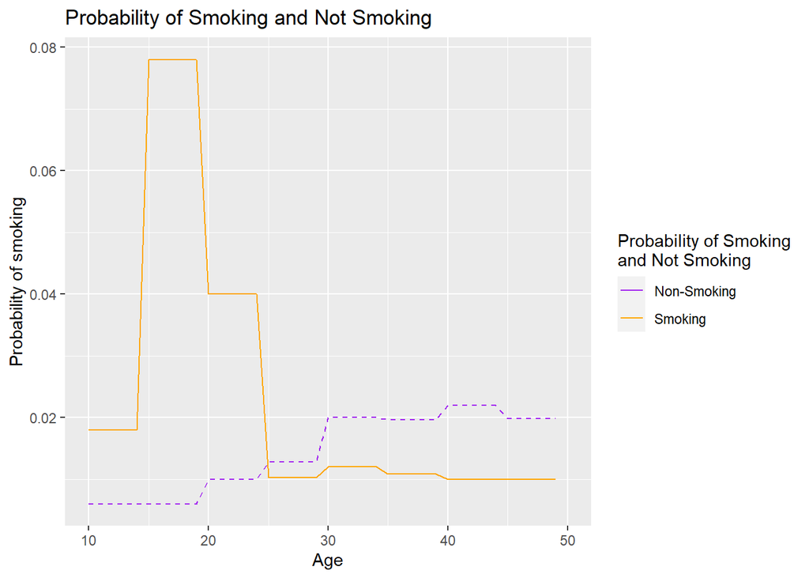

```r
#create a plot of age specific probability of smoking and not smoking between ages 10 and 50 for Italian males


IT_data %>%
  ggplot(aes(x = x)) +
  geom_line(aes(y = qx_ss, color = "Smoking"), linetype = "solid") +
  geom_line(aes(y = qx_ns, color = "Non-Smoking"), linetype = "dashed") +
  ylab("Probability of smoking") +
  xlab("Age") +
  scale_linetype_manual(name = "Probability of Smoking\nand Not Smoking", values = c("solid", "dashed")) +
  scale_color_manual(name = "Probability of Smoking\nand Not Smoking", values = c("purple", "orange")) +
  labs(color = "Line Type") +
  ggtitle("Probability of Smoking and Not Smoking")
```

*5. Could you calculate the average duration of quitting spells (periods of time when those who once smoked were not smoking) using the life table you have created? Why or why not?*

No. To calculate the duration of quitting spells you would need more logitundinal data and would likely need probabilities for a interval of less than one year. There is an equation in Schoen (1988) that it seems like you could use (equation 6) but a) you need the T value for this equation and b) The T value would be an unconditional value, it would include those who have never smoked and those who have smoked and quit.

*6. Related: the increment-decrement life table assumes a homogenous application of transition probabilities to all persons in a given state at a given age. Why might this assumption be problematic when studying smoking - particularly when using the three-state system defined here? If you had better data, how might you improve your ability to model the smoking experiences of this cohort? (If helpful, note that the true cumulative conditional probability of ever smoking for Italian males born in 1955 was 0.53, per Federico et al. 2007 AJPH).*

*7. Generate two additional lifetables that condition on smoking status at age 10. Generate a figure that summarizes the expected duration in each state (smoking and non-smoking) by the smoking status of the children at age 10.*

##Expected duration of smoking 10-50 years of age

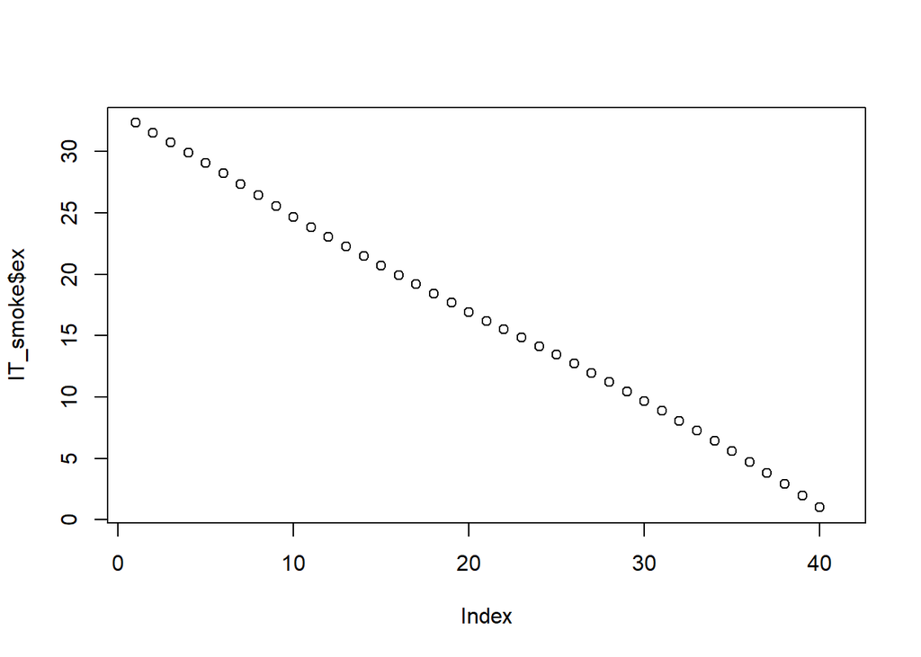

```r
#Conditional expectancies (eijx): average # of years spent in state j above age x, for individuals in state i at age x.

#expected duration of smoking for children aged 10 is the average  # of years spent smoking above age 10 for individuals smoking at age 10.

#need ex values for probability of exit while smoking.

#create new dataset

IT_smoke <- IT_data %>%
  select(x, qx_ss, qx_ns, qx_nsd, qx_sd)

# Initialize the variables with appropriate initial values
IT_smoke$lx_ns <- numeric(nrow(IT_smoke))
IT_smoke$lx_s <- numeric(nrow(IT_smoke))
IT_smoke$dx_1_2 <- numeric(nrow(IT_smoke))
IT_smoke$dx_2_1 <- numeric(nrow(IT_smoke))
IT_smoke$dx_2_4 <- numeric(nrow(IT_smoke))
IT_smoke$dx_1_3 <- numeric(nrow(IT_smoke))

#assign radix values for total population and two subpopulations (s and ns). lx is the number of individuals in each state i at exact age x


IT_smoke$lx_ns[1] <- 0
IT_smoke$lx_s[1] <- 2000

#Calculate dx values for lx0, or the number of individuals moving from state i to state j between ages x and x + 1. Four flows total ns = 1, s = 2, nsd = 3, sd = 4.
#initializecolumn[populate first row] <- round the result of (first row of lx * first row of qx, 5 decimals)

#transition from ns(1) to s(2), qx_ss (probabilty of starting smoking)
IT_smoke$dx_1_2[1] <- round(IT_smoke$lx_ns[1]* IT_smoke$qx_ss[1], digits = 5)

#transition from ns(1) to nsd(3), qx_nsd (probability of dying while nonsmoker)
IT_smoke$dx_1_3[1] <- round(IT_smoke$lx_ns[1]* IT_smoke$qx_nsd[1], digits = 5)

#transition from s(2) to ns(1), qx_ns (probability of quitting smoking)
IT_smoke$dx_2_1[1] <- round(IT_smoke$lx_s[1]* IT_smoke$qx_ns[1], digits = 5)

#transition from s(2) to sd(4), qx_sd (probabilty of dying while smoker)
IT_smoke$dx_2_4[1] <- round(IT_smoke$lx_s[1]* IT_smoke$qx_sd[1], digits = 5)


#Use a for loop to calculate the lx and dx values for all other ages
#notation for lx = lxi + 1 = lxi - dxij - dxv + dxji
#notation for dx = dxij = lxi * qxji

for(i in 2:nrow(IT_smoke)){
  IT_smoke$lx_ns[i] <- IT_smoke$lx_ns[i-1]-IT_smoke$dx_1_2[i-1]-IT_smoke$dx_1_3[i-1]+IT_smoke$dx_2_1[i-1]
  IT_smoke$lx_s[i] <- IT_smoke$lx_s[i- 1]-IT_smoke$dx_2_1[i-1]-IT_smoke$dx_2_4[i-1]+IT_smoke$dx_1_2[i-1]
  IT_smoke$dx_1_2[i] <- round(IT_smoke$lx_ns[i]*IT_smoke$qx_ss[i], digits = 5)
  IT_smoke$dx_2_1[i] <- round(IT_smoke$lx_s[i]*IT_smoke$qx_ns[i], digits = 5)
  IT_smoke$dx_2_4[i] <- round(IT_smoke$lx_s[i]*IT_smoke$qx_sd[i], digits = 5)
  IT_smoke$dx_1_3[i] <- round(IT_smoke$lx_ns[i]*IT_smoke$qx_nsd[i], digits = 5)
}


# Initialize Lx columns with NA values
IT_smoke$Lx_s <- rep(NA, nrow(IT_smoke))

#run for loop to populate Lx values
for (i in 1:(nrow(IT_smoke) - 1)) {
  IT_smoke$Lx_s[i] <- round(((IT_smoke$lx_s[i] + IT_smoke$lx_s[i + 1]) / 2), digits = 5)
}

# Create Tx column from Lx value
IT_smoke$Tx[1] <- sum(IT_smoke$Lx_s[1:40])
for (i in 2:nrow(IT_smoke)) {
  IT_smoke$Tx[i] <- round(IT_smoke$Tx[i-1] - IT_smoke$Lx_s[i-1], digits = 5)
}

IT_smoke$ex_s <- round(IT_smoke$Tx / IT_smoke$Lx_s, digits = 5)

plot(IT_smoke$ex)
```

```r
print(IT_smoke)
```

```
##     x  qx_ss  qx_ns      qx_nsd      qx_sd    lx_ns    lx_s  dx_1_2  dx_2_1
## 1  10 0.0180 0.0060 0.000363480 0.00036348   0.0000 2000.00 0.00000 12.0000
## 2  11 0.0180 0.0060 0.000350770 0.00035077  12.0000 1987.27 0.21600 11.9236
## 3  12 0.0180 0.0060 0.000383240 0.00038324  23.7034 1974.87 0.42666 11.8492
## 4  13 0.0180 0.0060 0.000457050 0.00045705  35.1169 1962.69 0.63210 11.7761
## 5  14 0.0180 0.0060 0.000566960 0.00056696  46.2449 1950.65 0.83241 11.7039
## 6  15 0.0780 0.0060 0.000695670 0.00069567  57.0901 1938.67 4.45303 11.6320
## 7  16 0.0780 0.0060 0.000865080 0.00086508  64.2294 1930.14 5.00989 11.5809
## 8  17 0.0780 0.0060 0.001024450 0.00102445  70.7448 1921.90 5.51810 11.5314
## 9  18 0.0780 0.0060 0.001097010 0.00109701  76.6857 1913.92 5.98148 11.4835
## 10 19 0.0780 0.0060 0.001102460 0.00110246  82.1036 1906.32 6.40408 11.4379
## 11 20 0.0400 0.0100 0.000752794 0.00215084  87.0469 1899.18 3.48188 18.9918
## 12 21 0.0400 0.0100 0.000742980 0.00212280 102.4913 1879.59 4.09965 18.7959
## 13 22 0.0400 0.0100 0.000763238 0.00218068 117.1114 1860.90 4.68446 18.6090
## 14 23 0.0400 0.0100 0.000779933 0.00222838 130.9466 1842.92 5.23786 18.4292
```

[output cut: 69 more lines]

```r
print(IT_smoke$ex[1])
```

```
## [1] 32.3483
```

##Expected duration of nonsmoking 10-50 years of age

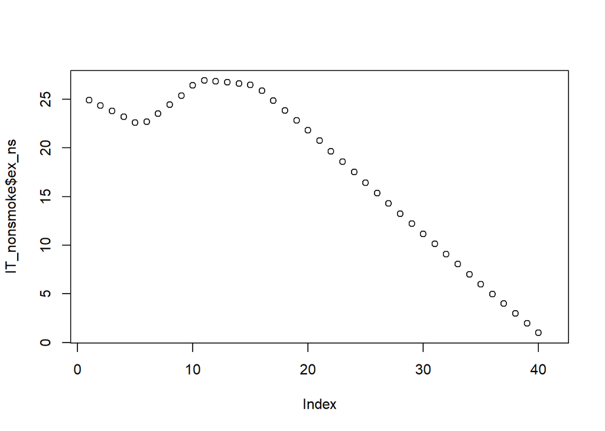

```r
#Conditional expectancies (eijx): average # of years spent in state j above age x, for individuals in state i at age x.

#expected duration of nonsmoking for children aged 10 is the average  # of years spent smoking above age 10 for individuals not smoking at age 10.

#need ex values for probability of exit while nonsmoking.

#create new dataset

IT_nonsmoke <- IT_data %>%
  select(x, qx_ss, qx_ns, qx_nsd, qx_sd)

# Initialize the variables with appropriate initial values
IT_nonsmoke$lx_ns <- numeric(nrow(IT_nonsmoke))
IT_nonsmoke$lx_s <- numeric(nrow(IT_nonsmoke))
IT_nonsmoke$dx_1_2 <- numeric(nrow(IT_nonsmoke))
IT_nonsmoke$dx_2_1 <- numeric(nrow(IT_nonsmoke))
IT_nonsmoke$dx_2_4 <- numeric(nrow(IT_nonsmoke))
IT_nonsmoke$dx_1_3 <- numeric(nrow(IT_nonsmoke))

#assign radix values for total population and two subpopulations (s and ns). lx is the number of individuals in each state i at exact age x


IT_nonsmoke$lx_ns[1] <- 98000
IT_nonsmoke$lx_s[1] <- 0

#Calculate dx values for lx0, or the number of individuals moving from state i to state j between ages x and x + 1. Four flows total ns = 1, s = 2, nsd = 3, sd = 4.
#initializecolumn[populate first row] <- round the result of (first row of lx * first row of qx, 5 decimals)

#transition from ns(1) to s(2), qx_ss (probabilty of starting smoking)
IT_nonsmoke$dx_1_2[1] <- round(IT_nonsmoke$lx_ns[1]* IT_nonsmoke$qx_ss[1], digits = 5)

#transition from ns(1) to nsd(3), qx_nsd (probability of dying while nonsmoker)
IT_nonsmoke$dx_1_3[1] <- round(IT_nonsmoke$lx_ns[1]* IT_nonsmoke$qx_nsd[1], digits = 5)

#transition from s(2) to ns(1), qx_ns (probability of quitting smoking)
IT_nonsmoke$dx_2_1[1] <- round(IT_nonsmoke$lx_s[1]* IT_nonsmoke$qx_ns[1], digits = 5)

#transition from s(2) to sd(4), qx_sd (probabilty of dying while smoker)
IT_nonsmoke$dx_2_4[1] <- round(IT_nonsmoke$lx_s[1]* IT_nonsmoke$qx_sd[1], digits = 5)


#Use a for loop to calculate the lx and dx values for all other ages
#notation for lx = lxi + 1 = lxi - dxij - dxv + dxji
#notation for dx = dxij = lxi * qxji

for(i in 2:nrow(IT_nonsmoke)){
  IT_nonsmoke$lx_ns[i] <- IT_nonsmoke$lx_ns[i-1]-IT_nonsmoke$dx_1_2[i-1]-IT_nonsmoke$dx_1_3[i-1]+IT_nonsmoke$dx_2_1[i-1]
  IT_nonsmoke$lx_s[i] <- IT_nonsmoke$lx_s[i-1]-IT_nonsmoke$dx_2_1[i-1]-IT_nonsmoke$dx_2_4[i-1]+IT_nonsmoke$dx_1_2[i-1]
  IT_nonsmoke$dx_1_2[i] <- round(IT_nonsmoke$lx_ns[i]*IT_nonsmoke$qx_ss[i], digits = 5)
  IT_nonsmoke$dx_2_1[i] <- round(IT_nonsmoke$lx_s[i]*IT_nonsmoke$qx_ns[i], digits = 5)
  IT_nonsmoke$dx_2_4[i] <- round(IT_nonsmoke$lx_s[i]*IT_nonsmoke$qx_sd[i], digits = 5)
  IT_nonsmoke$dx_1_3[i] <- round(IT_nonsmoke$lx_ns[i]*IT_nonsmoke$qx_nsd[i], digits = 5)
}



# Initialize Lx columns with NA values
IT_nonsmoke$Lx_ns <- rep(NA, nrow(IT_smoke))

#run for loop to populate Lx values
for (i in 1:(nrow(IT_nonsmoke) - 1)) {
  IT_nonsmoke$Lx_ns[i] <- round(((IT_nonsmoke$lx_ns[i] + IT_nonsmoke$lx_ns[i + 1]) / 2), digits = 5)
}


# Create Tx column from Lx value
IT_nonsmoke$Tx[1] <- sum(IT_nonsmoke$Lx_ns[1:40])
for (i in 2:nrow(IT_nonsmoke)) {
  IT_nonsmoke$Tx[i] <- round(IT_nonsmoke$Tx[i-1] - IT_nonsmoke$Lx_ns[i-1], digits = 5)
}

IT_nonsmoke$ex_ns <- round(IT_nonsmoke$Tx / IT_nonsmoke$Lx_ns, digits = 5)

plot(IT_nonsmoke$ex_ns)
```

```r
print(IT_nonsmoke)
```

```
##     x  qx_ss  qx_ns      qx_nsd      qx_sd   lx_ns     lx_s   dx_1_2   dx_2_1
## 1  10 0.0180 0.0060 0.000363480 0.00036348 98000.0     0.00 1764.000   0.0000
## 2  11 0.0180 0.0060 0.000350770 0.00035077 96200.4  1764.00 1731.607  10.5840
## 3  12 0.0180 0.0060 0.000383240 0.00038324 94445.6  3484.40 1700.021  20.9064
## 4  13 0.0180 0.0060 0.000457050 0.00045705 92730.3  5162.18 1669.145  30.9731
## 5  14 0.0180 0.0060 0.000566960 0.00056696 91049.7  6798.00 1638.895  40.7880
## 6  15 0.0780 0.0060 0.000695670 0.00069567 89400.0  8392.25 6973.201  50.3535
## 7  16 0.0780 0.0060 0.000865080 0.00086508 82415.0 15309.26 6428.368  91.8556
## 8  17 0.0780 0.0060 0.001024450 0.00102445 76007.2 21632.53 5928.559 129.7952
## 9  18 0.0780 0.0060 0.001097010 0.00109701 70130.5 27409.13 5470.182 164.4548
## 10 19 0.0780 0.0060 0.001102460 0.00110246 64747.9 32684.79 5050.335 196.1087
## 11 20 0.0400 0.0100 0.000752794 0.00215084 59822.3 37502.98 2392.891 375.0298
## 12 21 0.0400 0.0100 0.000742980 0.00212280 57759.4 39440.18 2310.375 394.4018
## 13 22 0.0400 0.0100 0.000763238 0.00218068 55800.5 41272.43 2232.020 412.7243
## 14 23 0.0400 0.0100 0.000779933 0.00222838 53938.6 43001.72 2157.544 430.0172
```

[output cut: 69 more lines]

```r
print(IT_nonsmoke$ex_ns[1])
```

```
## [1] 24.9041
```

#Generate a figure that summarizes the expected duration in each state (smoking and non-smoking) by the smoking status of the children at age 10.

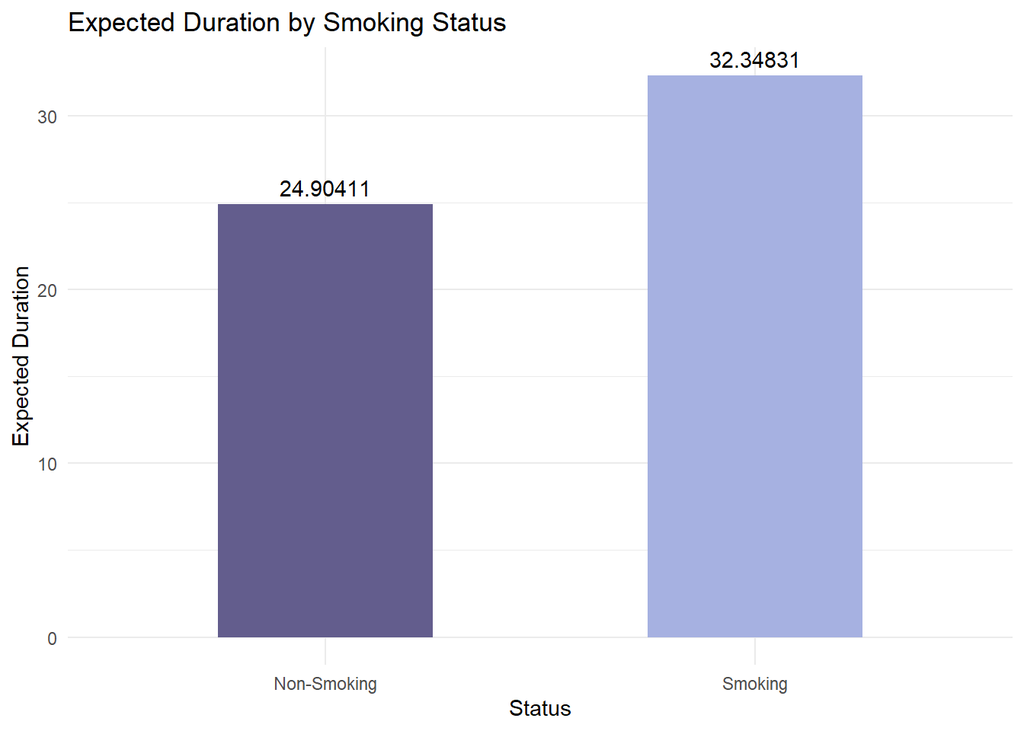

```r
# Combine the IT_smoke and IT_nonsmoke dataframes

plot_data <- data.frame(
  Status = c("Smoking", "Non-Smoking"),
  Expected_Duration = c(IT_smoke$ex_s[1], IT_nonsmoke$ex_ns[1])
)

# Create a ggplot2 bar plot with light purple and dark purple colors and no legend
ggplot(plot_data, aes(x = Status, y = Expected_Duration, fill = Status)) +
  geom_bar(stat = "identity", width = 0.5, position = position_dodge(width = 0.75)) +
  geom_text(aes(label = Expected_Duration), vjust = -0.5) +
  ylab("Expected Duration") +
  xlab("Status") +
  scale_fill_manual(values = c("Smoking" = "#A6B1E1", "Non-Smoking" = "#635D8D")) +  # Light and dark purple
  ggtitle("Expected Duration by Smoking Status") +
  theme_minimal() +
  theme(legend.position = "none")  # Remove the legend
```